# MAT150 - Summer 2023

Phd. Anabela Romina Turlione

Digipen, Bilbao

# Domain and range of composite functions

**Composition**

Given two functions $f(x)$ and $g(x)$, the **composite function** $ f\circ g$ is defined by

\begin{equation} \big( f\circ g\big)(x)=f\big(g(x)\big)\end{equation}

- Domain of $ f\circ g$: it is the set of all $x$ in the domain of $g$ such that $ g(x)$ is in the domain of $f$.

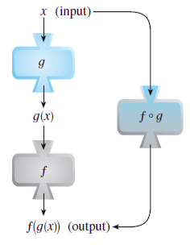

**Exercise 1**

If $f(x)=\sqrt{x}$ and $g(x)=\sqrt{2-x}$, find each function and its domain.

(a) $f\circ g$

(b) $g\circ f$

(c) $f\circ f$

(d) $g\circ g$

**Solution:**

(a) $f\circ g=\sqrt[4]{2-x}$, Domain: $(-\infty,2]$

(b) $g\circ f=\sqrt{2-\sqrt{x}}$, Domain: $[0,4]$

(c) $f\circ f=\sqrt[4]{x}$, Domain: $[0,\infty)$

(d) $g\circ g=\sqrt{2-\sqrt{2-x}}$, Domain: $[-2,2]$

- In the study of the domain of a composite function, first of all, simplify the function as much as possible.

**Exercise 2:** Find the domain of $f$, $g$ and $f\big(g(x)\big)$

\begin{equation} f(x)=\frac{x-2}{x-1}, ~~ q(x)=\frac{x+2}{x+1} \end{equation}

**Exercise 3:**

Find the domain of the following curves.

# Surfaces in R3

A multi-variable function is rule that assigns to some entry(ies) an output.

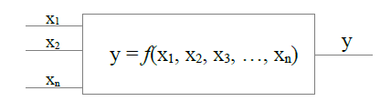

We are going to study the particular case in which $y\in \Re$, then $f: x_1, x_2, ...., x_n \in \Re^n \rightarrow \Re$

Example: $z=f(x,y)=x^2-5y+10$

```python
import matplotlib.pyplot as plt
import numpy as np

def plot_z1():
    x = np.linspace(-10,10,30)
    y = np.linspace(-10,10,30)
    X, Y = np.meshgrid(x,y)


    Z = X**2-5*Y+10


    ax = plt.axes(projection='3d')
    ax.plot_surface(X, Y, Z, rstride=1, cstride=1,
                    cmap='viridis', edgecolor='none')

    plt.xlabel('x', fontsize=20)
    plt.ylabel('y', fontsize=20)

    plt.rcParams['figure.figsize'] = [7, 7]
    ax.set_title('surface');
    ax.view_init(10, 30)
```

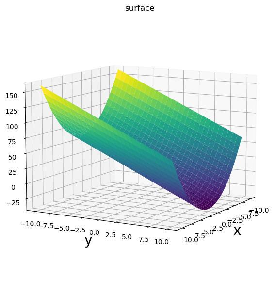

```python
plot_z1()
```

In the same way than in 2D we can define some curves that are not functions by means of the implicit equation $f(x,y)=0$, in 3D we can use $f(x,y,z)=0$.

# Basic Surfaces

Planes: $A(x-x_0)+B(y-y_0)+C(z-z_0)=0$, $A,~B,~C$ real constants, $x,~y~ and~z\in \Re$

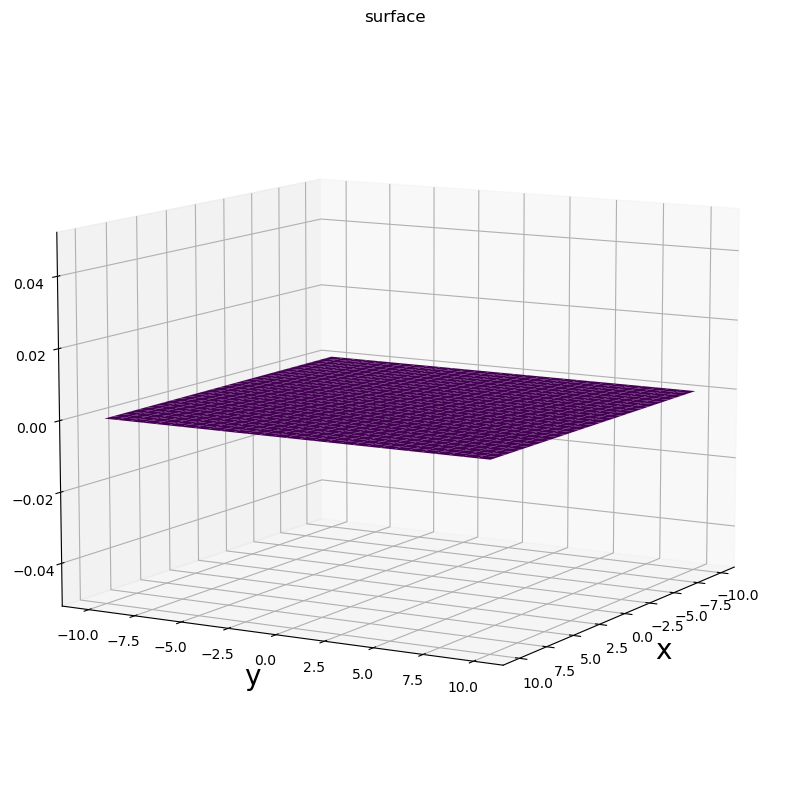

```python
A,B,C,x0,y0,z0 =0,0,1,0,0,0

plot_z2(A,B,C,x0,z0,y0)
```

$y=2x+1$

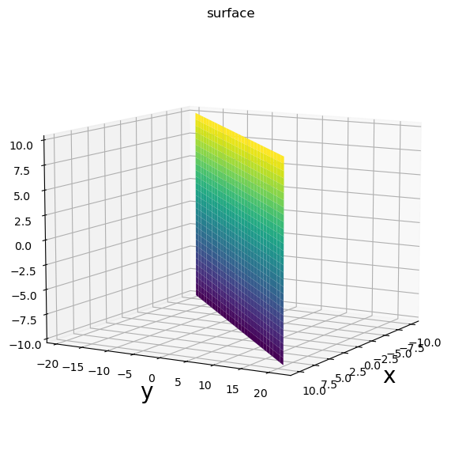

```python
plot_z3(2,1)
```

$y=3$

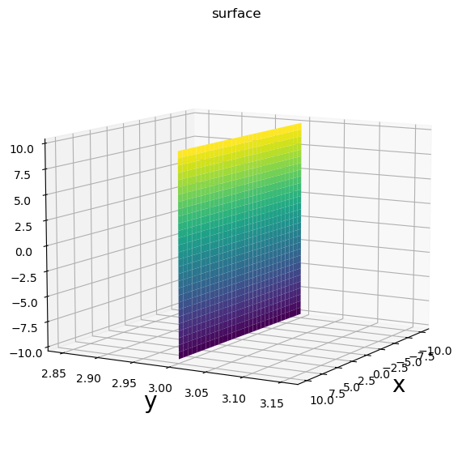

```python
plot_z3(0,3)
```

# Cylinders

- In general, $f(x,y)=0$ (parallel to z), $g(x,z)=0$ (parallel to y) or $h(y,z)=0$ (parallel to x).
- According to their **section area** the cylinders are named “circular cylinders, elliptical cylinders, parabolic cylinders, etc.
- Common to all of them, is that their intersection with planes parallel to their axis of symmetry will return in lines.

**Circular cylinder** \begin{equation} (x-x_0)^2+(y-y_0)^2=R^2 \end{equation}

**Example:**

## Parametric equation

We use cylindrical coordinates:

\begin{equation} \left\lbrace \begin{array}{ll} x=r\cos(\phi) \\ y=r\sin(\phi)\\ z=t \end{array} \right.,~ \phi ~in~ [0,2\pi],~t~in~[0,L] \end{equation}

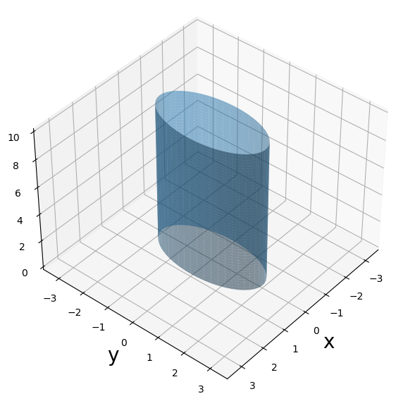

```python
plot_z4(1,2)
```

**Elliptical cylinder** \begin{equation} \frac{(x-x_0)^2}{a^2}+\frac{(y-y_0)^2}{b^2}=1 \end{equation}

**Example:**

\begin{equation} \frac{x^2}{9}+y^2=1 \end{equation}

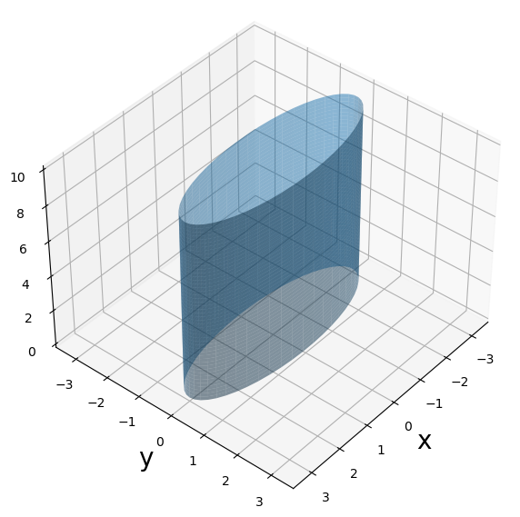

```python
plot_z4(3,1)
```

## Parabolic cylinder

\begin{equation} (x-x_0)^2=a(y-y_0) \end{equation}

**Example**

## Parametric equation

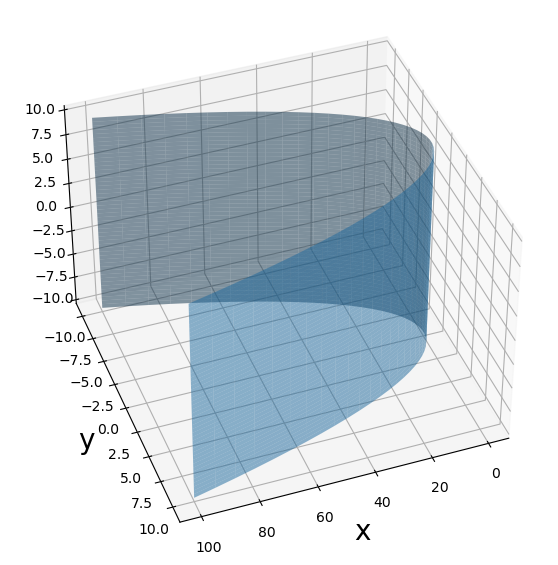

```python
plot_z5()
```

# Sphere

\begin{equation} (x-x_0)^2+(y-y_0)^2+(z-z_0)^2=r^2 \end{equation}

**Example:**

\begin{equation} x^2+y^2+z^2=1 \end{equation}

## Parametric equation

We use spherical coordinates:

\begin{equation} \left\lbrace \begin{array}{ll} x=r\sin(\theta)\cos(\phi) \\ y=r\sin(\theta)\sin(\phi)\\ z=r\cos(\theta) \end{array} \right.,~ \theta ~\in~ [0,\pi],~ \phi ~in~ [0,2\pi] \end{equation}

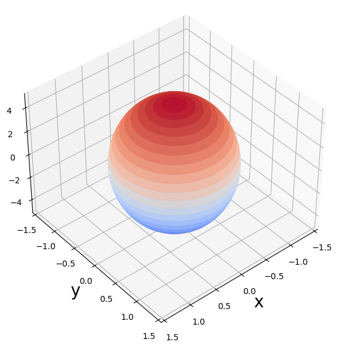

```python
plot_z6(1,1,5)
```

## Paraboloide

\begin{equation} \bigg(\frac{x-x_0}{a}\bigg)^2 + \bigg(\frac{y-y_0}{b}\bigg)^2=z-z_0 \end{equation}

## Parametric equation

\begin{equation} \left\lbrace \begin{array}{ll} x=t \\ y=u\\ z=\big(\frac{t-t_0}{a}\big)^2 + \big(\frac{u-u_0}{b}\big)^2 \end{array} \right. \end{equation}

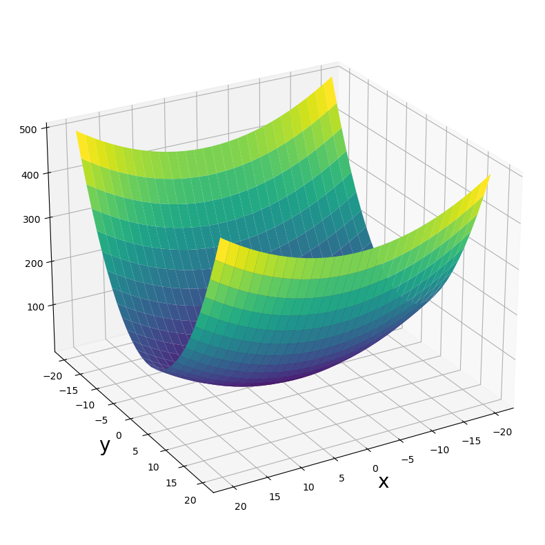

```python
a,b=2,1
x0,y0,z0=0,0,0
plot_z5(a,b)
```

**Projections**

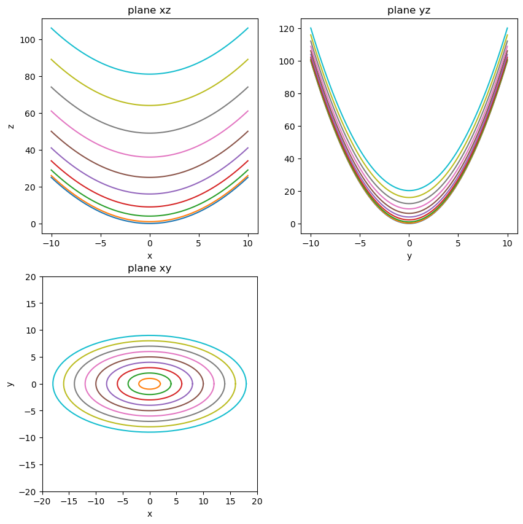

```python
plot_z5_projections(a,b)
```

## A cone

\begin{equation} \bigg(\frac{x-x_0}{a}\bigg)^2 + \bigg(\frac{y-y_0}{b}\bigg)^2=\bigg(\frac{z-z_0}{c}\bigg)^2 \end{equation}

## Parametric equation

\begin{equation} \left\lbrace \begin{array}{ll} x=at\cos(\theta)/c +x_0\\ y=at\sin(\theta)/c+y_0\\ z=t+z_0 \end{array} \right.,~\theta \in [0,2\pi], ~t \in [-L1,L2] \end{equation}

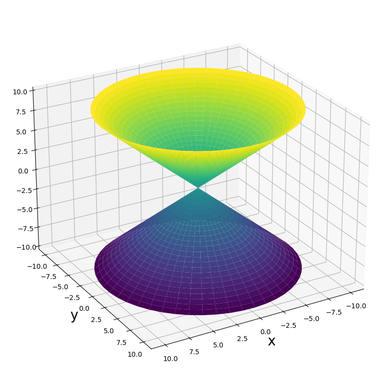

```python
x0,y0,z0=0,0,0
a,b,c=1,1,1

plot_z6(a,b,c,x0,y0,z0)
```

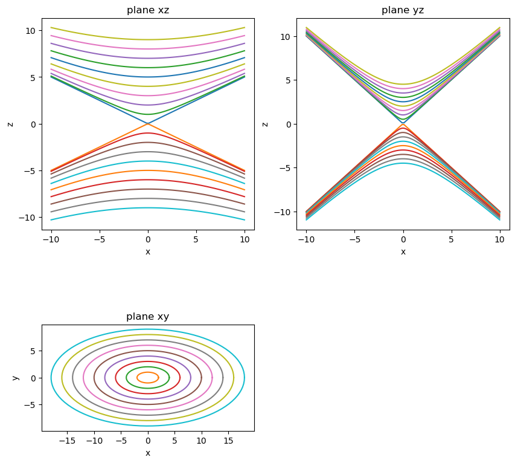

```python
x0,y0,z0=0,0,0
a,b,c=2,1,1

plot_z6_projections(a,b,c,x0,y0,z0)
```

# Domain and range in $\Re^3$

- Domain is the **region** in the xy-plane for which the function is defined.
- If the domain covers ALL the region it will be: $Domain=\Re^2$ or $Domain=(-\infty,\infty)\times(-\infty,\infty)$
- If the Domain is defined for $x\in[a,b]$ and $y\in[c,d]$, it is expressed as: $Domain=[a,b]\times[c,d]$

**Exercise 3**

Find and sketch the domain of:

1. $z=\sqrt{1-x^2}-\sqrt{1-y^2}$
1. $z=\sqrt{x+y+1}$
1. $z=\frac{\sqrt{2-x^2-y}}{x-1}$
1. $z=x\ln(x-y^2)$
1. $z=\frac{\sec(\pi y)}{\ln(x-y)}$
1. $x^2+(y-1)^2+z^2=9$